# Smoothing

November 16, 2015

## A simple example

```r
library(Biobase)
library(SpikeIn)
library(hgu95acdf)
data(SpikeIn95)
```

http://genomicsclass.github.io/book/

## Scatterplot

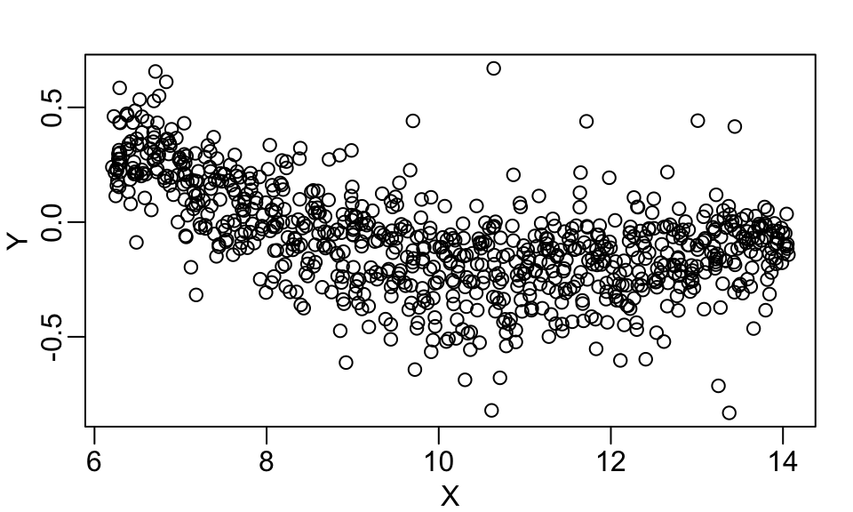

```r
library(rafalib)
mypar()
plot(X,Y)
```

http://genomicsclass.github.io/book/

## Fit a line

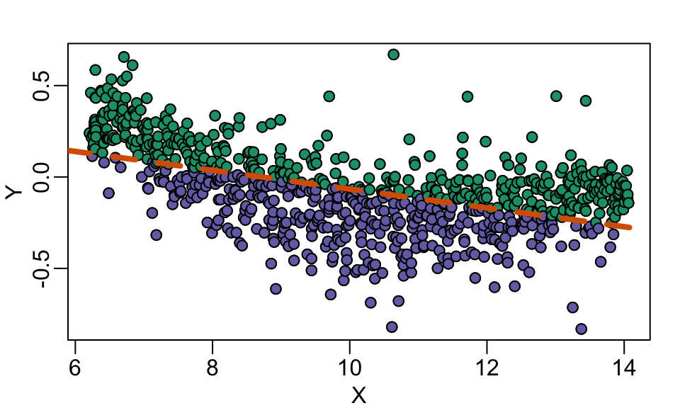

```r
mypar()
plot(X,Y)
fit <- lm(Y~X)
points(X,Y,pch=21,bg=ifelse(Y>fit$fitted,1,3))
abline(fit,col=2,lwd=4,lty=2)
```

http://genomicsclass.github.io/book/

## Bin smoothing

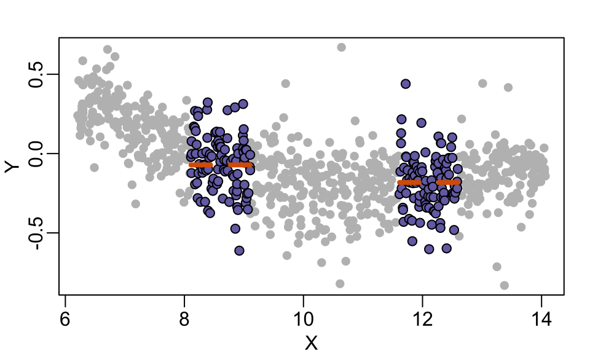

http://genomicsclass.github.io/book/

## Lots of bins

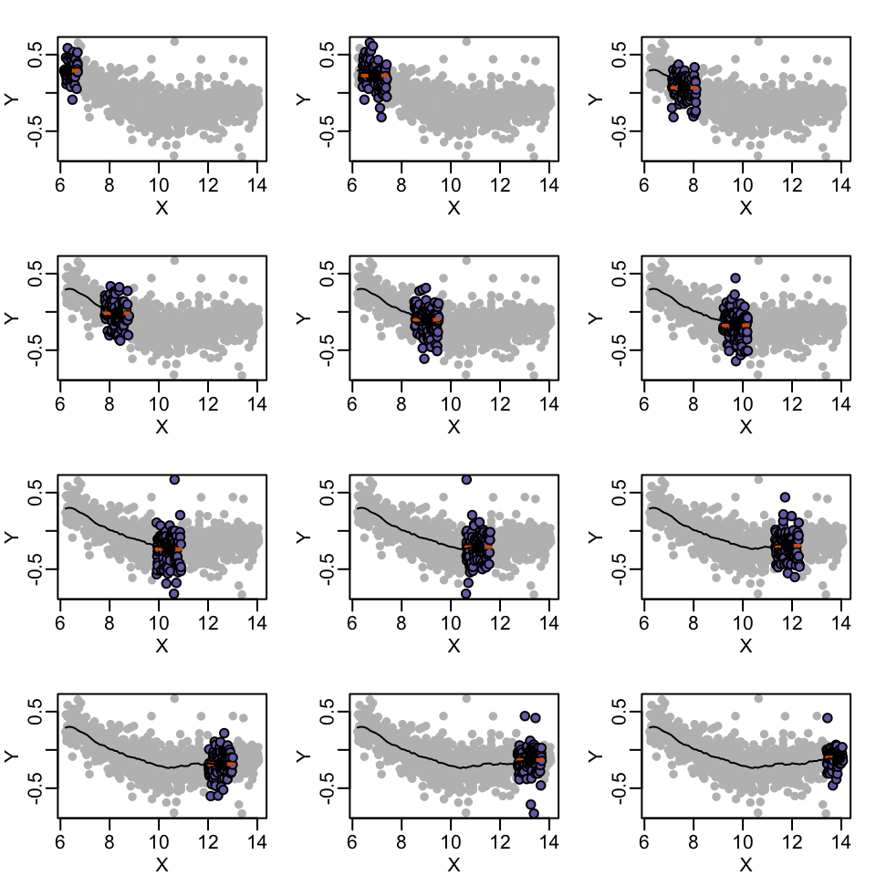

http://genomicsclass.github.io/book/

## Final result

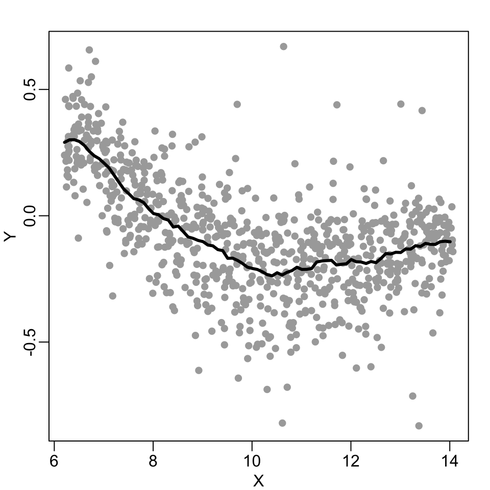

http://genomicsclass.github.io/book/

## Loess

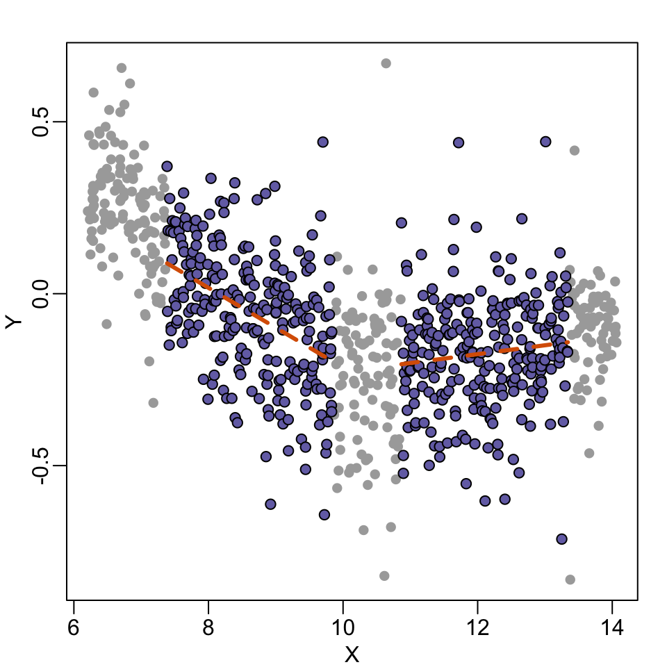

http://genomicsclass.github.io/book/

## Lots of bins

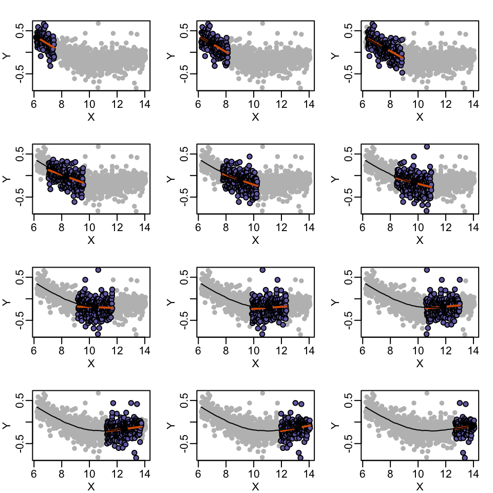

http://genomicsclass.github.io/book/

## Final result

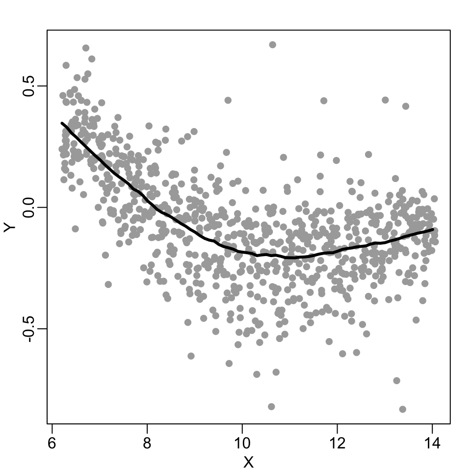

http://genomicsclass.github.io/book/

## Loess function

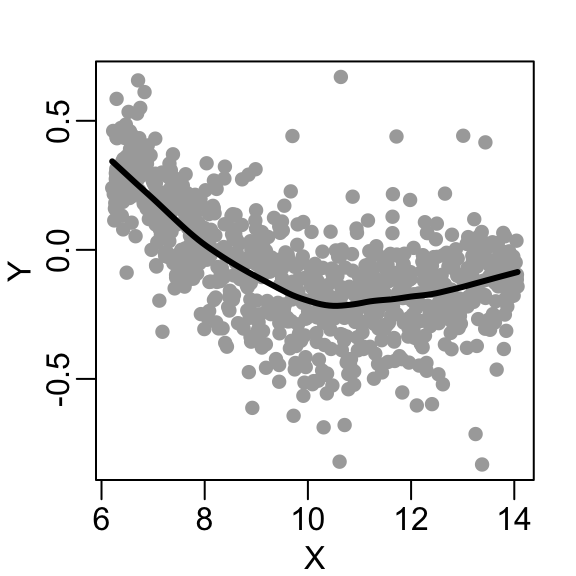

```r
fit <- loess(Y~X, degree=1, span=1/3)
newx <- seq(min(X),max(X),len=100)
smooth <- predict(fit,newdata=data.frame(X=newx))
mypar ()
plot(X,Y,col="darkgrey",pch=16)
lines(newx,smooth,col="black",lwd=3)
```

http://genomicsclass.github.io/book/

## Data are rarely linear

- It is rare for the exact regression function \(f\) to fall into space spanned by linear combinations of covariates
- So \[g(x;\theta) = \theta_1 + \theta_2 x, x \in I\] may miss important features.

## Example data

Earth scientists believe that there might have been a major climate change that caused a mass extinction between the Cretacious and Tertiary periods. This is called the [KTB boundary](http://www.princeton.edu/geosciences/people/keller/publications/pdf/2011_Keller_SEPM_100_KTB_def.pdf) and was \(\approx 66\) million years ago. The ratio of isotopes of Strontium in fossils tells us about the chemical composition in the atmosphere during different geological periods.

\[^{87}\delta \mbox{Sr} = \left( \frac{ ^{87}\mbox{Sr}/^{86}\mbox{Sr sample}}{^{87}\mbox{Sr}/^{86}\mbox{Sr sea water}} - 1\right) \times 10^5.\]

## Strontium data

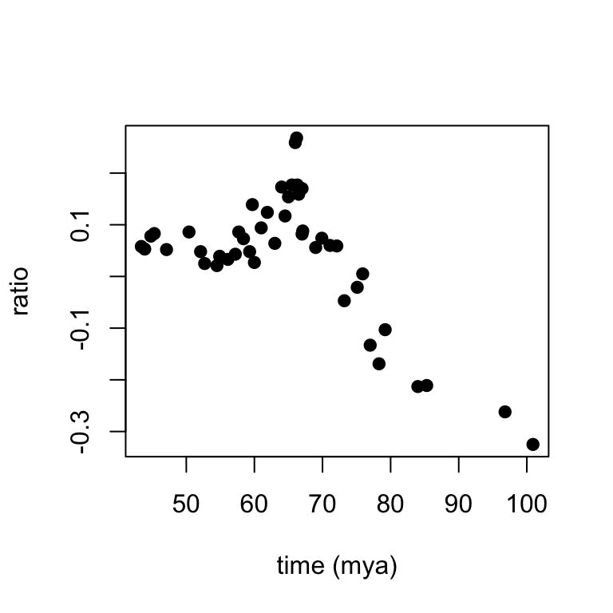

```r
dat = read.table("http://www.biostat.jhsph.edu/~ririzarr/Teaching/754/Data/Sr.dat")
plot(dat,xlab="time (mya)",ylab="ratio",pch=19)
```

## Polynomial model

The polynomial might fit better here:

\[g(x;\theta) = \theta_1 + \theta_2 x + \dots + \theta_k x^{k-1}, x\in I\]

- Note that the space \(\cal G = {\cal P}_k\) consists of polynomials having degree at most \(k-1\).
- In exceptional cases, we have reasons to believe that the regression function \(f\) is in fact a high-order polynomial.
- For historical values of \(^{87}\delta Sr\) we consider polynomials simply because our scientific intuition tells us that \(f\) should be smooth.

## Computational issue

The basis of monomials

\(B_j(x) = x^{j-1} \mbox{ for } j=1,\dots,k\)

is not well suited for numerical calculations.

- This basis is ill conditioned for \(k\) larger than \(8\) or \(9\)
- R uses orthogonal [Chebyshev polynomials](http://en.wikipedia.org/wiki/Chebyshev_polynomials) intead `?poly` (e.g. \(T_0(x)=1\), \(T_1(x) = x\), \(T_{n+1}(x) = 2xT_n(x) - T_{n-1}(x)\))

## Alternative set of polynomials you could use

An alternative to polynomials is to consider the space \({\cal PP}_k(t)\) of piecewise polynomials with break points \(t=(t_0,\dots,t_{m+1})'\). Given a sequence \(a = t_0 < t_1 < \dots < t_m < t_{m+1} = b\), construct \(m+1\) (disjoint) intervals \[I_l = [t_{l-1},t_l), 1 \leq l \leq m \mbox{ and } I_{m+1} = [t_m,t_{m+1}]\] whose union is \(I=[a,b]\).

Define the piecewise polynomials of order \(k\) as

\[g(x) = \left\{ \begin{array}{cc} g_1(x) = \theta_{1,1} + \theta_{1,2} x + \dots + \theta_{1,k} x^{k-1},&x \in I_1\\ \vdots&\vdots\\ g_{m+1}(x) = \theta_{m+1,1} + \theta_{m+1,2} x + \dots + \theta_{m+1,k} x^{k-1},&x \in I_{k+1}. \end{array} \right.\]

- But it can be hard to justify the breaks

## Continuous first derivatives

- Basic idea - make the piecewise polynomials have continuous first derivative
- Start with space of piecewise polynomials \[{\cal PP}_k(t)$ with $t = (t_1,\dots,t_m)'\]
- We can put constrains on the behavior of the functions \(g\) at the break points.
- A trick is to write \(g \in {\cal PP}_k(t)\) in *the truncated basis power*: \[g(x) = \theta_{0,1} + \theta_{0,2} x + \dots + \theta_{0,k} x^{k-1} +\] \[, \theta_{1,1}(x-t_1)^0_+ + \theta_{1,2} (x-t_1)^1_+ + \dots + \theta_{1,k} (x-t_1)^{k-1}_+ +\] \[ \vdots\] \[ \theta_{m,1}(x-t_m)^0_+ + \theta_{m,2} (x-t_m)^1_+ + \dots + \theta_{m,k} (x-t_m)^{k-1}_+\] where \((\cdot)_+ = \max(\cdot,0)\).

## Continuous first derivatves continued

- Written in this way the coefficients \(\theta_{1,1},\dots,\theta_{1,k}\) record the jumps in the different derivative from the first piece to the second.
- Now we can force constrains, such as continuity, by putting constrains like \(\theta_{1,1}=0\) etc…
- Notice that the constrains reduce the number of parameters. This is in agreement with the fact that we are forcing more smoothness.

## Cubic splines

\[g(x) = \theta_{0,1} + \theta_{0,2} x + \dots + \theta_{0,4} x^3 + \theta_{1,k} (x-t_1)^{3}+ \dots + \theta_{m,k} (x-t_m)^{3}\]

- Note: It is always possible to have less restrictions at knots where we believe the behavior is "less smooth", e.g for the Sr ratios, we may have "unsmoothness" around KTB.
- We can write this as a linear space, but it isn't convenient for computations `bs()` creates this basis but computationally convenient
- There is asymptotic theory for all this but we are going to do usual hand waving. Note \[E[ f(x) - g(x) ] = O(h_l^{2k} + 1/n_l)\] where \(h_l\) is the size of the interval for \(x\) and \(n_l\) is the number of points.

## `bs()` for strontium data

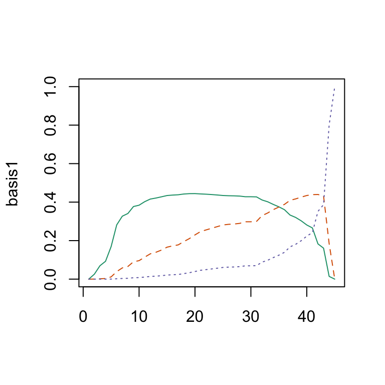

```r
library(splines)
basis1 = bs(dat[,1],df=3)
matplot(basis1,type="l")
```

## `bs()` and regression

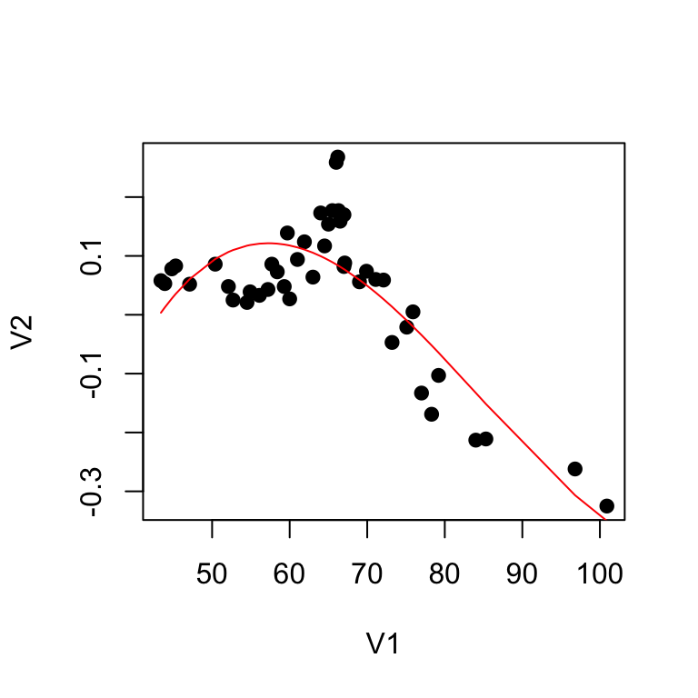

```r
basis1 = bs(dat[,1],df=3)
lm1 = lm(dat[,2] ~ basis1)
plot(dat,pch=19); lines(dat[,1],lm1$fitted,col="red")
```

## Splines in terms of spaces and sub-spaces

\[ {\cal G} =\{ g: g(x) = \sum_{j=1}^p \theta_j \beta_j(x), x \in I, (\theta_1,\dots,\theta_p) \in {\mathbb R}^p \} \]

## Natural splines

- Natural splines add the constraint that the function must be linear after the knots at the end points
- This forces 2 more restrictions since \(f''\) must be 0 at the end points, i.e the space has \(k + 4 - 2\) parameters because of these 2 constraints.

## Natural smoothing splines

- What happens if the knots coincide with the dependent variables \(\{X_i\}\). Then there is a function \(g \in \cal G\), the space of cubic splines with knots at \((x_1,\dots,x_n)\), with \(g(x_i) = y_i, i,\dots,n\), i.e. we haven't smoothed at all.
- Among all functions \(g\) with two continuous first derivatives, find the one that minimizes the penalized residual sum of squares \[\sum_{i=1}^n \{ y_i - g(x_i) \}^2 + \lambda \int_a^b \{g''(t)\}^2 dt\] where \(\lambda\) is a fixed constant, and \(a \leq x_1 \leq \dots \leq x_n \leq b\).
- It can be shown (Reinsch 1967) that the solution to this problem is a natural cubic spline with knots at the values of \(x_i\) (so there are \(n-2\) interior knots and \(n-1\) intervals). Here \(a\) and \(b\) are arbitrary as long as they contain the data.
- It seems that this procedure is over-parameterized since a natural cubic spline as this one will have \(n\) degrees of freedom. However we will see that the penalty makes this go down.

## Computational aspects

- We use the fact that the solution is a natural cubic spline and write the possible answers as: \[g(x) = \sum_{j=1}^{n} \theta_j B_j(x)\] where \(\theta_j\) are the coefficients and \(B_j(x)\) are the basis functions.
- Notice that if these were cubic splines the functions lie in a \(n+2\) dimensional space, but the natural splines are an \(n\) dimensional subspace.
- Let \(B\) be the \(n \times n\) matrix defined by \[ B_{ij} = B_j(x_i)\] and a penalty matrix \(\Omega\) by \[ \Omega_{ij} = \int_a^b B_i''(t)B_j''(t) \, dt\]

## Computational aspects continued

Now we can write the penalized criterion as

\[(y - B\theta)'(y - B\theta) +\lambda\theta'\Omega\theta\]

- It seems there are no boundary derivatives constraints but they are implicitly imposed by the penalty term.
- Setting derivatives with respect to \(\theta\) equal to 0 gives the estimating equation:\[(B'B + \lambda\Omega)\theta = B'y.\]
- The \(\hat{\theta}\) that solves this equation will give us the estimate \(\hat{g} = B \hat{\theta}\).

## Is this a linear smoother?

\[\hat{g} = B \theta = B(B'B + \lambda \Omega)^{-1} B'y = ({\mathbf I} + \lambda {\mathbf K})^{-1}y\]

where \({\mathbf K} = B -1 ' \Omega B^{-1}\). Notice we can write the criterion as

\[(y - g)'(y - g) + \lambda g' {\mathbf K} g\]

If we look at the "kernel" of this linear smoother it is similar to the other smoothers in this class.

## `ns()` for strontium data

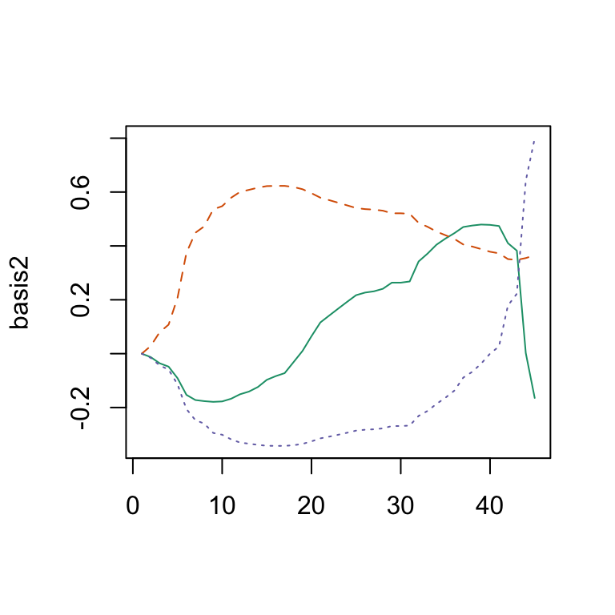

```r
basis2 = ns(dat[,1],df=3)
matplot(basis2,type="l")
```

## `ns()` and regression

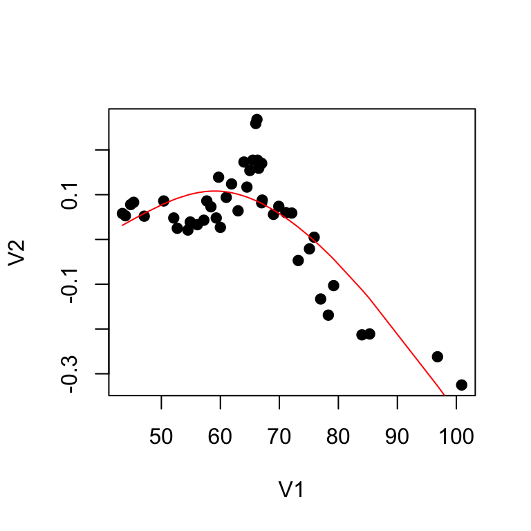

```r
basis2 = ns(dat[,1],df=3)
lm2 = lm(dat[,2] ~ basis2)
plot(dat,pch=19); lines(dat[,1],lm2$fitted,col="red")
```